# Cancer Evenness Replication

## Evenness of Cancer Subtypes is near 70%

This code chunk subsets the data to look not at 15 categories of cancer, but at each of the 69 individual cancer subtypes available in the data.

```r
# Helper Function
CancerCleaning <- function(site) {
  which(cancerX$cancerSite == site)
}

# vector to be used in function
vector <- c(4, 5, 8, 13, 16, 17, 18, 19, 20, 21, 23, 35, 41, 42, 48, 49, 50, 58, 68, 69, 70, 71, 73, 74, 75, 76, 77, 86, 87, 88, 89, 100, 106, 108, 109, 110, 11, 112, 113, 115, 116, 117, 125, 132, 133, 145, 148, 150, 151, 152, 158, 160, 161, 162, 163, 172, 174, 183, 184, 200, 210, 211, 213, 217, 224, 225, 226, 242, 243)

# Create the desired data frame outside of the function
z <- unlist(lapply(vector, CancerCleaning))
cancerX2 <- cancerX[z, c(2:4)]

CancerEvennessX <- function(ageGroupID) {
  # First subset the cancer data frame by the ageGroup column
  x <- cancerX2[cancerX2$ageGroup == ageGroupID, ]

  # str(x)

  # Then sum all of the data by cancer type
  x2 <- aggregate(. ~ cancerSite, data = x, FUN=sum)

  # str(x2)

  # Remove cancer types with no data (non-existant
  # species in population of interest)
  x3 <- x2$numberOfCases[which(x2$numberOfCases != 0)]

  # str(x3)

  # Calculate the evenness and print to the console
  x4 <- GetEvenness(x3)
  print(paste0("Evenness of Age Group ", ageGroupID," = ", x4), quote = FALSE)
  x4
}

x <- unlist(lapply(1:19, CancerEvennessX))
```

```
## [1] Evenness of Age Group 1 = 0.518958765092867
## [1] Evenness of Age Group 2 = 0.520307462273511
## [1] Evenness of Age Group 3 = 0.598742178869825
## [1] Evenness of Age Group 4 = 0.661810063142057
## [1] Evenness of Age Group 5 = 0.688683516618552
## [1] Evenness of Age Group 6 = 0.709474889904872
## [1] Evenness of Age Group 7 = 0.721213204849441
## [1] Evenness of Age Group 8 = 0.721086399677296
## [1] Evenness of Age Group 9 = 0.720915494073223
## [1] Evenness of Age Group 10 = 0.729127261731701
## [1] Evenness of Age Group 11 = 0.737577218077924
## [1] Evenness of Age Group 12 = 0.722731344909576
## [1] Evenness of Age Group 13 = 0.704512415746358
## [1] Evenness of Age Group 14 = 0.694755434093302
## [1] Evenness of Age Group 15 = 0.697112296996015
## [1] Evenness of Age Group 16 = 0.705901867585838
## [1] Evenness of Age Group 17 = 0.718995594914796
## [1] Evenness of Age Group 18 = 0.729574872741235
## [1] Evenness of Age Group 19 = 0.673668561981316
```

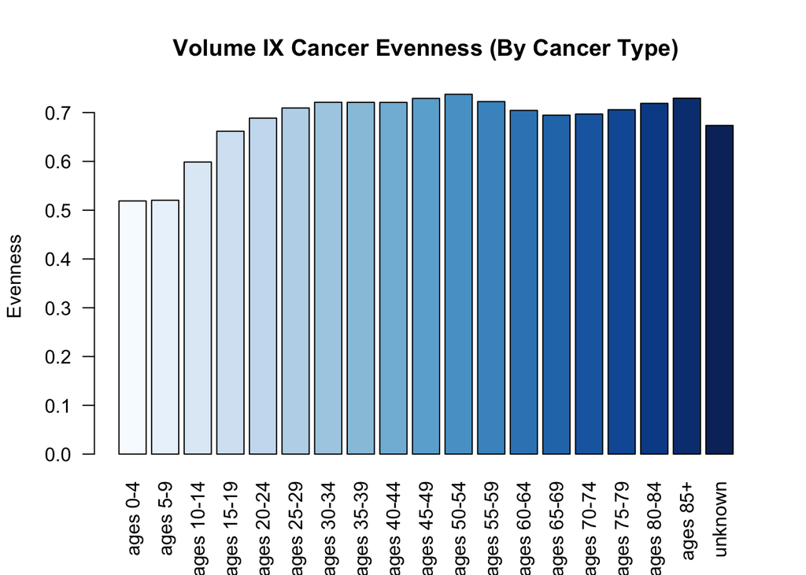

```r
par(las=2) #rotates x-axis labels
barplot(x,
        col = colorRampPalette(brewer.pal(9,"Blues"))(19),
        main = "Volume IX Cancer Evenness (By Cancer Type)",
        ylab = "Evenness",
        names.arg = c("ages 0-4","ages 5-9",
                      "ages 10-14","ages 15-19",
                      "ages 20-24","ages 25-29",
                      "ages 30-34","ages 35-39",
                      "ages 40-44","ages 45-49",
                      "ages 50-54","ages 55-59",
                      "ages 60-64","ages 65-69",
                      "ages 70-74","ages 75-79",
                      "ages 80-84","ages 85+",
                      "unknown")
        )
```

## Appendix:

Sanity check to be sure I understand the data structure.

From the dictionary, Tongue (C01-02) should be coded as cancerSite number 5.

The Tongue cancer site should be a summation of the next two cancer sites (6 and 7), which correspond to the base of the tongue (6) and other unspecified parts (7).

To test if this is true, I can subset the data and sum the number of cases.

```r
z <- cancerX[which(cancerX$cancerSite == 5), c(2, 4)]
sum1 <- sum(z$numberOfCases)

p <- cancerX[which(cancerX$cancerSite == 6), c(2, 4)]
q <- cancerX[which(cancerX$cancerSite == 7), c(2, 4)]
sum2 <- sum(p$numberOfCases, q$numberOfCases)

sum1 == sum2
```

```
## [1] TRUE
```

Thankfully, this is the case. So I do understand the data.